# g112_summary

## G112 Summary Lac Léman

### Incidence of industrial pellets (GPI) by location and signifigant values

Plastic industrial pellets or GPI have been found at all lakes in the present study. The quantity of pellets found and the frequency at which they are identified varies from one lake to another and from one location to another.

Here we summarize the incidence of GPI nationally and regionally on Lac Léman. We focus on the locations that have results equal to or greater than the 90th percentile.

**Francais**

### Incidence des granulés industriels par lieu et valeur significative

Des granulés industriels en plastique ou GPI ont été trouvés dans tous les lacs de la présente étude. La quantité de GPI trouvés et la fréquence à laquelle ils sont identifiés varient d'un lac à l'autre et d'un endroit à l'autre.

Nous résumons ici l'incidence des GPIs au niveau national et régional sur le Lac Léman. Nous nous concentrons sur les endroits dont les résultats sont égaux ou supérieurs au 90e percentile.

#### Discussion:

For the period, the total GPI identified is 1,487 out of 40,578 total items or ~ 3.7% of all trash on the beach. As a frame of reference, cigarette ends are between 12% and 20% of the total.

Of the lakes with 20 samples or more Bielersee has the highest median and frequency of all the project lakes. Lac Léman has the highest average value as well as greatest number of locations with at least one GPI. Brienzersee, with only 4 samples, leads all project lakes except in mean pcs/m (table 2).

**Francais**

Pour la période, GPI total identifié est de 1'487 sur 40'578 articles au total, soit environ 3,7 % de tous les déchets sur la plage. Comme cadre de référence, les mégots de cigarettes représentent entre 12 et 20 % du total.

Parmi les lacs avec 20 échantillons ou plus, Bielersee présente la médiane et la fréquence le plus élevée de tous les lacs du projet. Le Lac Léman a la valeur moyenne la plus élevée ainsi que le plus grand nombre de sites avec au moins un GPI. Le Brienzersee, avec seulement 4 échantillons, est en tête de tous les lacs du projet, sauf en ce qui concerne la moyenne des pcs/m (tableau 2).

Lac Léman

Of the 74 surveys 35 reported at least one GPI and 20/74 reported siginfigant GPI values. The median value for the lake remains at zero (table 4) but the 75th percentile jumps to 0.2 pcs/m, compared to 0.03 nationally (table 1).

There are siginfigant values reported in all three sections of the lake (map 2, map 3). The highest concentration are in the communes of Morges, St Sulpice and Lausanne (fig 5).

1. Genève
2. Morges
3. St. Sulpice
4. Lausanne
5. St. Gingolph

**Francais**

De les 74 enquêtes, 35 ont rapporté au moins un GPI et 20/74 ont rapporté des valeurs de GPI importantes. La valeur médiane reste à zéro (tableau 4) mais le 75e percentile passe à 0,2 pcs/m, contre 0,03 au niveau national (tableau 1).

Des valeurs siginfigantes sont signalées dans les trois sections du lac (carte 2, carte 3). Les concentrations les plus élevées se trouvent dans les communes de Morges, St Sulpice et Lausanne (fig 5).

#### Lac Léman GPI utilisation and distribution

There are several suppliers and users of GPI in the Léman basin and upstream on the Rhône a few are in close proximity to locations with signifigant values or situated on an intersecting river or canal (map 3).

Il existe plusieurs fournisseurs et utilisateurs de GPI dans le bassin Lémanique et en amont sur le Rhône; quelques-uns sont à proximité de lieux ayant des valeurs importantes ou situés sur un fleuve ou un canal qui se croisent (carte 3).

questions or comments: analyst@hammerdirt.ch

### Methods

#### **Data source, time frame, geographic scope and collection methods**

The data for this analysis is the results from beach-litter surveys conducted in Switzerland from April 1, 2020 through January 18, 2021.

All surveys that were conducted on Bielersee, Neuenburgersee, Thunersee, Walensee, Zurichsee, Lac Léman, Brienzersee and Lago Magiore were considered.

The data was collected according to the protocol described here https://www.plagespropres.ch/. In brief all visible data is collected along a beach within a measured distance from the waters edge. The width of the survey area depends on the terrain and the water level. The visible strand line or the nearest physical structure defines the width of a survey.

Surveys were conducted by the following organizations:

1. hammerdirt
2. Association pour le Sauvegarde du leman
3. Solid Waste Management Ecole Polytechnique Federal
4. Ecole International de Geneve
5. Precious plastic leman
6. Why isn't your association here?

This analysis is an open source document. The working note book is available in the repository located here https://github.com/hammerdirt-analyst/iqals.

#### Scope of surveys

The scope of the surveys includes the total population levels and land use configuration for the adjacent municipality. Land use is quantified by calculating the m² of space attributed to buildings wtihin 500m of the survey location and the total length in meters of roads within 1000m of the survey location*.

The results and survey locations can be classified according to the following attributes:

1. M² of buildings within 500m of the survey
2. Total length of streets/roads within 1000m of the survey
3. Number of river/canal intersections within 1500m of the survey
4. Population of the surounding municipality

*Values are calculated using https://shop.swisstopo.admin.ch/en/products/landscape/tlm3D

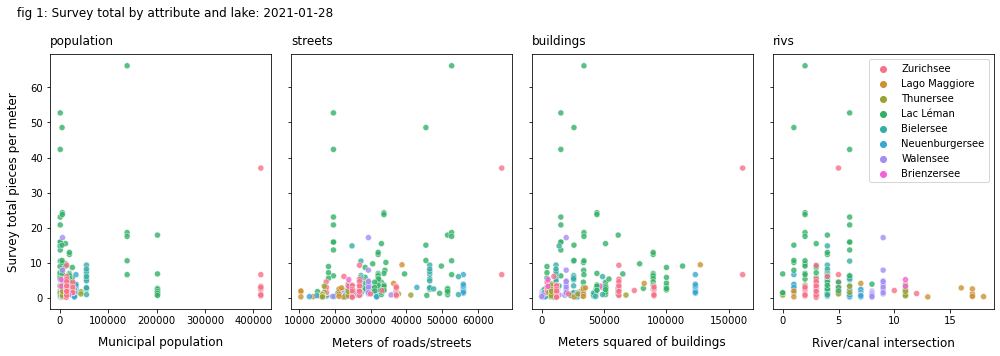

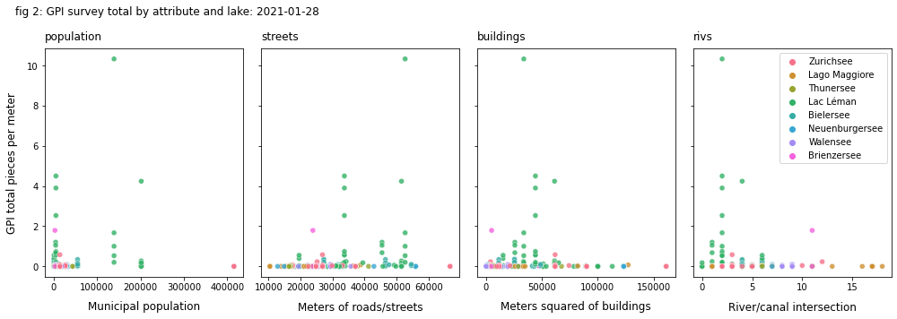

#### Geographic scope of surveys

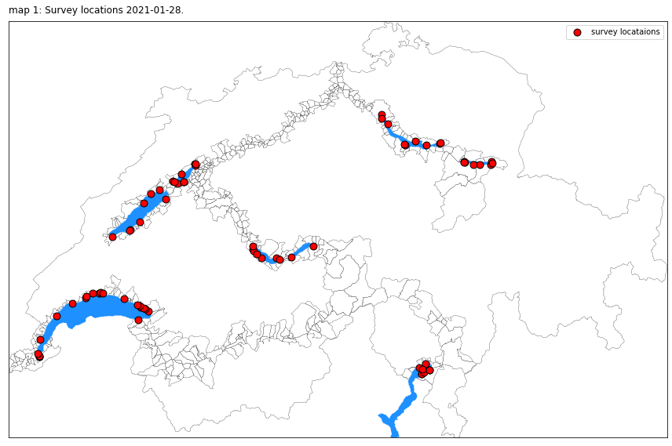

### Survey results

For the period, the total GPI identified is 1,487 out of 40,578 total items or ~ 3.7% of all trash on the beach. As a frame of reference, cigarette ends are between 12% and 20% of the total.

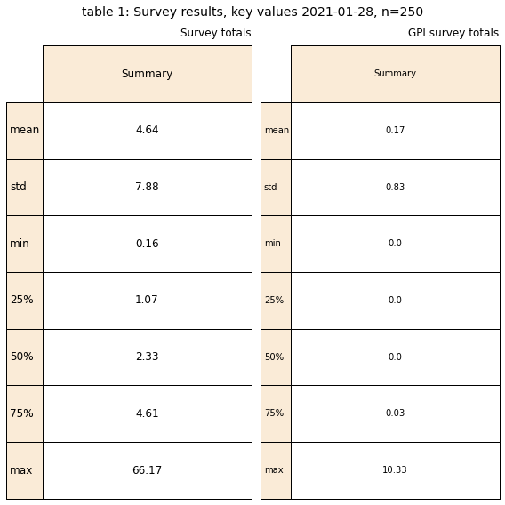

### Regional summary

Of the lakes with 20 samples or more Bielersee has the highest median and frequency of all the project lakes. Lac Léman has the highest average value as well as greatest number of locations with at least one GPI. Brienzersee, with only 4 samples, leads all project lakes except in mean pcs/m (table 2).

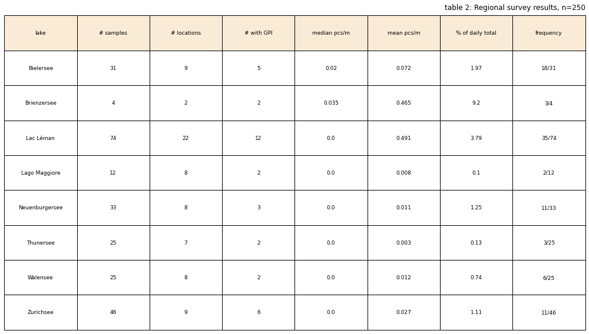

### Distribution of survey results

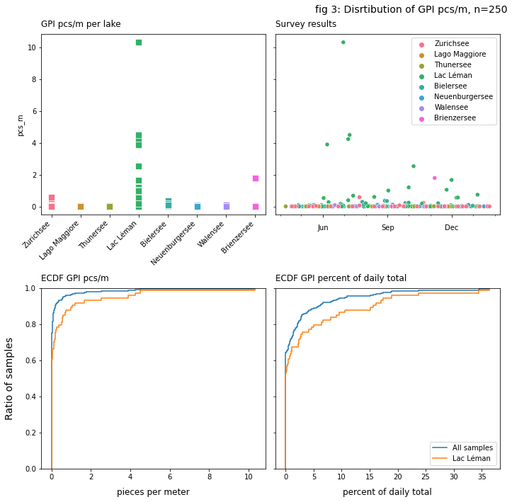

### Definition of signifigant values

Signifigant values are those survey values that are equal to or exceed the 90th percentile of all survey results.

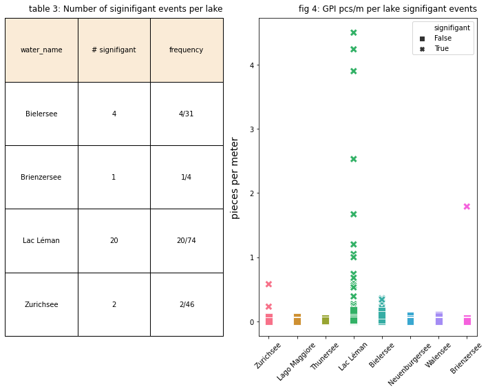

A portion of the variance in the national results could be attributed to survey location. The chances of finding the code of interest for every 10 meters of survey length is different depending on the lake:

The chance of finding AT LEAST one G112 for every 10 meters of survey nationally is: ~13.6

The chance of finding AT LEAST one G112 for every 10 meters of survey on Lac Léman is: ~33.8%

The chance of finding AT LEAST one G112 for every 10 meters of survey on Bielersee is: ~19.4%

### Geographic scope GPI

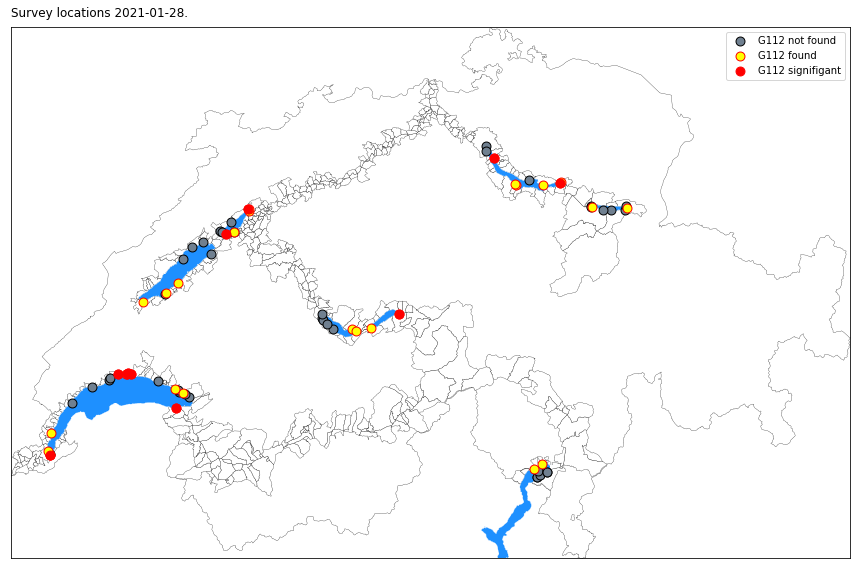

### Lac Léman results and conclusions

Of the 74 surveys 35 reported at least one GPI and 20/74 reported siginfigant GPI values. The median value for the lake remains at zero (table 4) but the 75th percentile jumps to 0.2 pcs/m, compared to 0.03 nationally (table 1).

There are siginfigant values reported in all three sections of the lake (map 2, map 3). The highest concentration are in the communes of Morges, St Sulpice and Lausanne (fig 5).

1. Genève
2. Morges
3. St. Sulpice
4. Lausanne
5. St. Gingolph

[figure not shown]

[figure not shown]

### Lac Léman GPI use and distribution

There are several suppliers and users of GPI in the Léman basin and upstream on the Rhône a few are in close proximity to locations with signifigant values or situated on an intersecting river or canal (map 3).

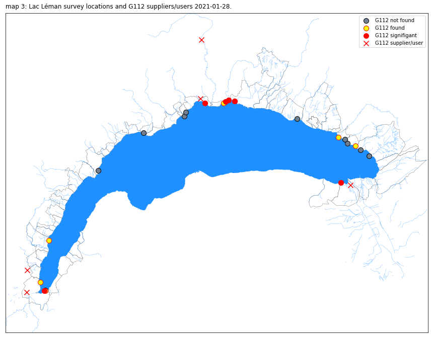

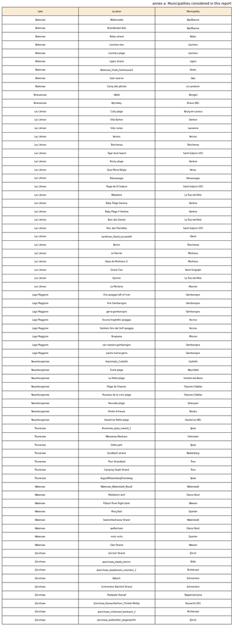

#### Hopefully that just worked for you

if not contact analyst@hammerdirt.ch